# 10.9 Seasonal Models - More General Model

Chad Madding

March 8, 2020

## Model

$$(1-B^{12})(1-1.5B+0.8B^2)(X-50)=a_t$$

```r
x=gen.aruma.wge(n=200, s=12,phi = c(1.5,-0.8), sn=87)
```

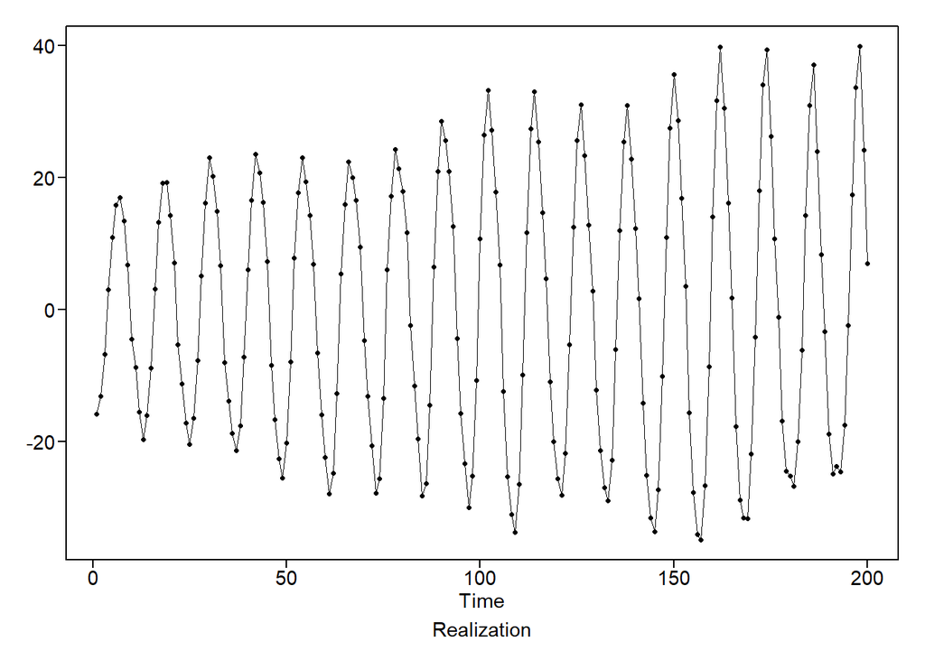

```r
# add in the mean
x=x+50
```

## Visualize The Data

See what we are dealing with:

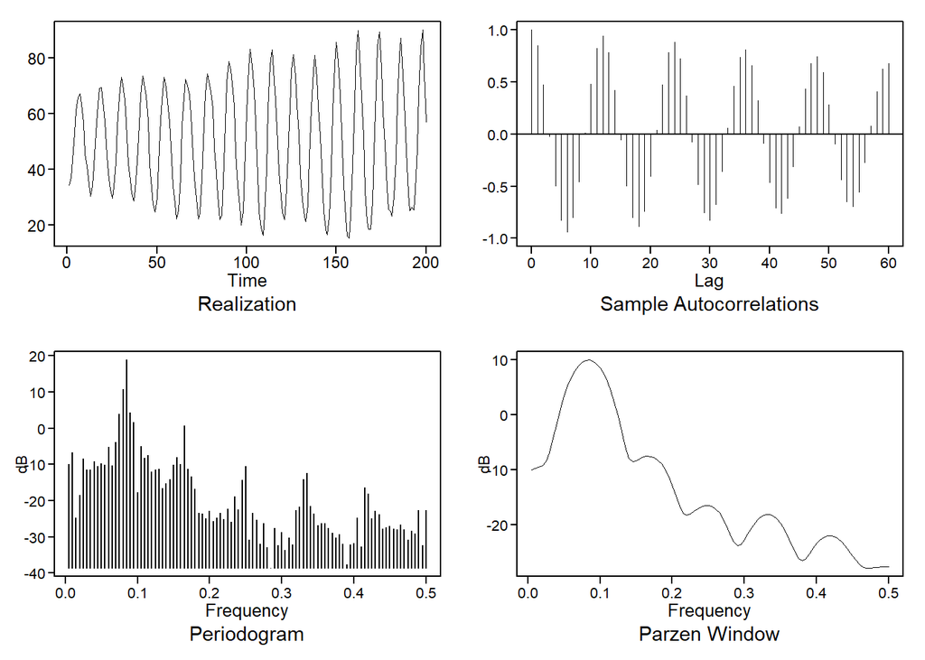

```r
plot=plotts.sample.wge(x,lag.max = 60)
```

## Overfit Factor Table

Use a number over what you think the seasonality looks to be.

```r
d15=est.ar.wge(x,p=17, type = 'burg')
```

```
##
## Coefficients of Original polynomial:
## 1.3330 -0.5138 -0.1128 -0.1721 0.1693 -0.0499 -0.0030 -0.0388 0.0590 -0.1264 0.0688 0.8973 -1.2428 0.4347 0.0738 0.1762 -0.1623
##
## Factor                 Roots                Abs Recip    System Freq
## 1-1.7276B+0.9985B^2    0.8651+-0.5031i      0.9992       0.0838
## 1-1.0028B+0.9955B^2    0.5036+-0.8665i      0.9977       0.1662
## 1+1.0010B+0.9936B^2   -0.5037+-0.8676i      0.9968       0.3337
## 1-0.0157B+0.9930B^2    0.0079+-1.0035i      0.9965       0.2487
## 1+1.7329B+0.9899B^2   -0.8753+-0.4941i      0.9949       0.4182
## 1+0.9836B             -1.0166               0.9836       0.5000
## 1-0.9136B              1.0945               0.9136       0.0000
## 1-1.4286B+0.7747B^2    0.9220+-0.6638i      0.8802       0.0993
## 1-0.7137B              1.4011               0.7137       0.0000
## 1+0.7516B+0.3366B^2   -1.1166+-1.3132i      0.5801       0.3621
##
##
```

Look in the factor table for patterns matching know seasonal tables.

Here is a factor table of $(1-B^{12})$.

```r
#(1-B^12)
factor.wge(c(rep(0,11),1))
```

```
##
## Coefficients of Original polynomial:
## 0.0000 0.0000 0.0000 0.0000 0.0000 0.0000 0.0000 0.0000 0.0000 0.0000 0.0000 1.0000
##
## Factor                 Roots                Abs Recip    System Freq
## 1-1.0000B+1.0000B^2    0.5000+-0.8660i      1.0000       0.1667
## 1-1.0000B              1.0000               1.0000       0.0000
## 1-1.7321B+1.0000B^2    0.8660+-0.5000i      1.0000       0.0833
## 1+1.0000B+1.0000B^2   -0.5000+-0.8660i      1.0000       0.3333
## 1-0.0000B+1.0000B^2    0.0000+-1.0000i      1.0000       0.2500
## 1+1.7321B+1.0000B^2   -0.8660+-0.5000i      1.0000       0.4167
## 1+1.0000B             -1.0000               1.0000       0.5000
##
##
```

**Note:** The factor 1-0.9136B is not very close to the unit circle, but since all other factors are consistent with $(1-B^{12})$ we conclude that this overfit table suggests $(1-B^{12})$ also.

## Transform

Base on the overfit table we can now transform the data to remove the seasonality.

Transform data to create $Y_t=(1-B^{12})X_t$

```r
#rep will repeat the 11 zeros then we can add a one at the end
y=artrans.wge(x,phi.tr = (c(rep(0,11),1)))
```

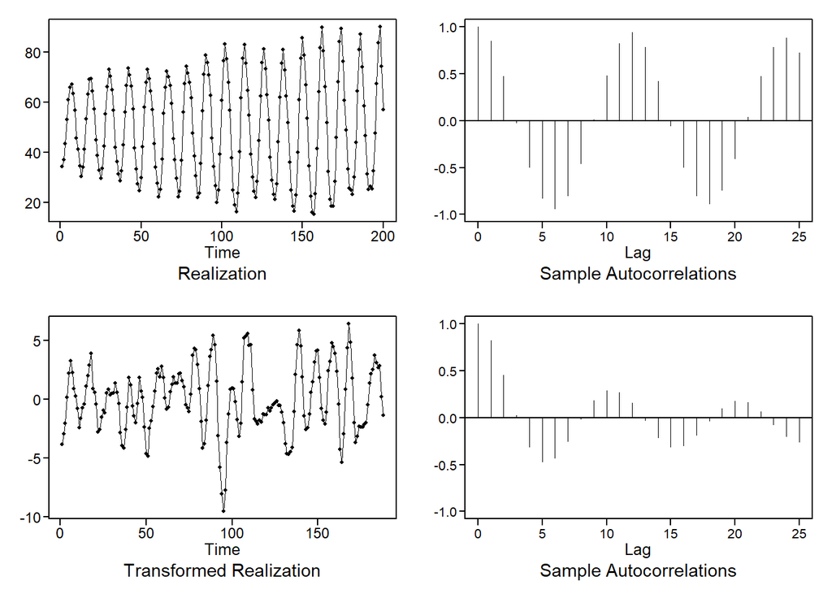

The transformed data appear stationary, so we use AIC to identify a model.

We use **aic5.wge** to model the transformed data (y) When using AIC to model data that has been stationarized using the seasonal transform $(1-B^{12})$, it is good practice to allow a range of p values to include s to uncover any seasonal stationary information that might be in the data. In R code to follow, we consider the range p=0:13 and q=0:3

```r
# y is the transformed data
aic5.wge(y,p=0:13,q=0:3)
```

```
## ---------WORKING... PLEASE WAIT...
##
##
## Five Smallest Values of  aic
```

|  | p | q | aic |
| --- | --- | --- | --- |
| 19 | 4 | 2 | 0.06290065 |
| 9 | 2 | 0 | 0.06764617 |
| 20 | 4 | 3 | 0.06910374 |
| 13 | 3 | 0 | 0.07338218 |
| 10 | 2 | 1 | 0.07361012 |

AIC selects an ARMA(4,2) model. Factoring the ARMA(4,2) model we obtain:

```r
est = est.arma.wge(y,p=4, q=2, factor = TRUE)
```

```
##
## Coefficients of Original polynomial:
## 1.8831 -2.1943 1.5169 -0.6321
##
## Factor                 Roots                Abs Recip    System Freq
## 1-0.4098B+0.8135B^2    0.2519+-1.0798i      0.9019       0.2135
## 1-1.4733B+0.7771B^2    0.9480+-0.6231i      0.8815       0.0925
##
##
```

```r
est$phi
```

```
## [1]  1.8831035 -2.1942981  1.5169278 -0.6321408
```

```r
est$theta
```

```
## [1]  0.4957013 -0.9262404
```

**Note:** The dominant behavior of the transformed data is a pseudo cyclic behavior of length about 10 $(f_0=.10)$. The factors associated with frequency about $f_0=.2$ essentially cancel.

We can look for a simpler model using BIC. Use the y data.

```r
aic5.wge(y,p=0:13,q=0:3,type='bic')
```

```
## ---------WORKING... PLEASE WAIT...
##
##
## Five Smallest Values of  bic
```

|  | p | q | bic |
| --- | --- | --- | --- |
| 9 | 2 | 0 | 0.1192915 |
| 13 | 3 | 0 | 0.1422426 |
| 10 | 2 | 1 | 0.1424706 |
| 11 | 2 | 2 | 0.1692218 |
| 17 | 4 | 0 | 0.1700640 |

BIC picks a simpler AR(2) model. This is consistent with:

- The pseudo cyclic data
- Damping cyclical sample autocorrelations

**Decision:** We choose to model the transformed data as an AR(2).

```r
est2=est.ar.wge(y,p=2)
```

```
##
## Coefficients of Original polynomial:
## 1.4653 -0.7597
##
## Factor                 Roots                Abs Recip    System Freq
## 1-1.4653B+0.7597B^2    0.9644+-0.6215i      0.8716       0.0911
##
##
##
## Coefficients of Original polynomial:
## 1.4653 -0.7597
##
## Factor                 Roots                Abs Recip    System Freq
## 1-1.4653B+0.7597B^2    0.9644+-0.6215i      0.8716       0.0911
##
##
```

We can now write our model using data collected from **est.ar.wge**.

```r
#Get the phi's for the model
est2$phi
```

```
## [1]  1.4652837 -0.7596714
```

```r
#Get the White Noise Var
est2$avar
```

```
## [1] 1.036377
```

```r
#Figure the mean with the original x data
mean(x)
```

```
## [1] 49.77867
```

#### Our final model:

$$(1-B^{12})(1-1.47B+0.76B^2)(x_t-49.78)=a_y\ \sigma^2_a=1.04$$

#### The Original Model:

$$(1-B^{12})(1-1.5B+0.8B^2)(X-50)=a_t$$

### 10.9.4 Concept Check

Consider the attached Southwest Airlines flight delay data (SWADelay.csv). Use **est.ar.wge()** to overfit an **AR(15)** model with the Burg estimates. We are trying to gauge if there is sufficient evidence to suggest a $(1-B^{12})$ factor is in the model. Look at the factor table, and answer the following questions.

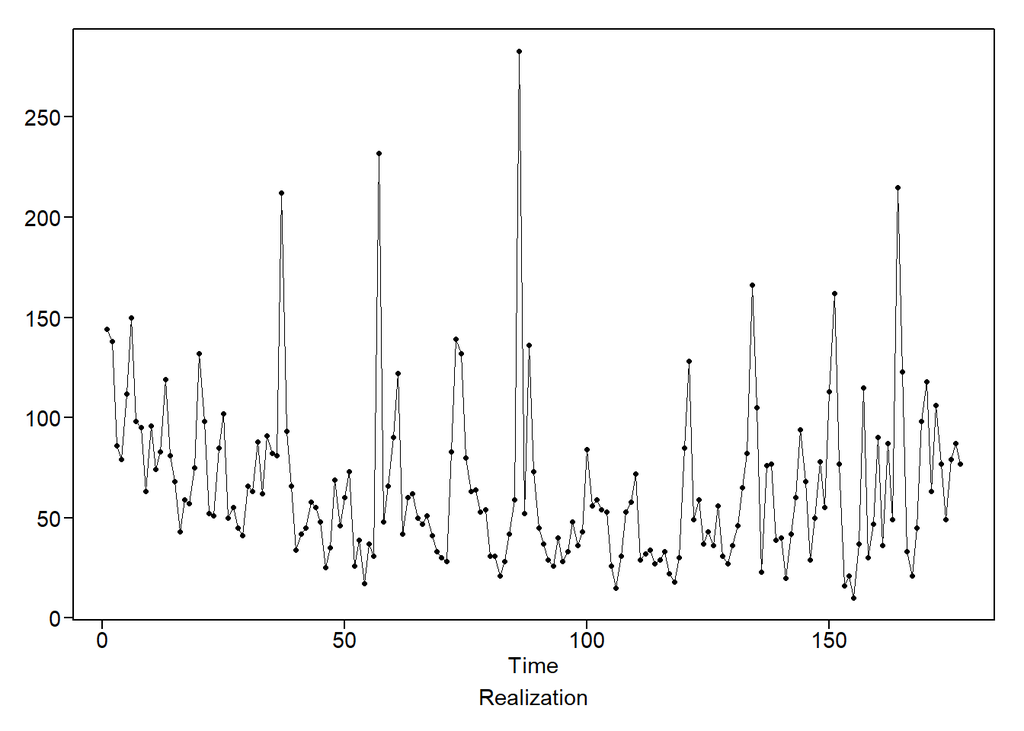

```r
#read in the data
SWA = read.csv("swadelay.csv",header = TRUE)
plotts.wge(SWA$arr_cancelled)
```

```r
#Get and an estimate using the arr_delay information
#Overfitting with and AR(15)
d15SW=est.ar.wge(SWA$arr_delay,p=15, type = 'burg')
```

```
##
## Coefficients of Original polynomial:
## 0.4443 0.0482 -0.0541 0.0820 0.0090 0.0304 0.0410 -0.0837 0.0588 0.0568 0.0252 0.3759 -0.0127 -0.0074 -0.1486
##
## Factor                 Roots                Abs Recip    System Freq
## 1-0.9700B              1.0310               0.9700       0.0000
## 1-0.9946B+0.9342B^2    0.5323+-0.8872i      0.9666       0.1640
## 1-1.6636B+0.9322B^2    0.8923+-0.5259i      0.9655       0.0848
## 1+0.9229B             -1.0836               0.9229       0.5000
## 1+1.6328B+0.8443B^2   -0.9669+-0.4994i      0.9189       0.4241
## 1-0.1460B+0.8319B^2    0.0877+-1.0928i      0.9121       0.2372
## 1+0.7038B+0.7209B^2   -0.4882+-1.0719i      0.8490       0.3180
## 1+0.7885B+0.5243B^2   -0.7520+-1.1584i      0.7241       0.3416
## 1-0.7182B              1.3924               0.7182       0.0000
##
##
```

*10.9.4* What is the root associated with the factor (from the factor table you generated) that would be matched with the $(1-B)$ term from the $(1-B^{12})$ factor table?

Express your response rounded to four decimal places. *1.0310*

*10.9.5* Look at the system frequencies from the factor table you generated. What is the system frequency associated with the the factor that would be matched with the $(1 - 1.732B + B^2)$ factor from the $(1-B^{12})$ factor table?

```r
factor.wge(phi = c(rep(0,11),1))
```

```
##
## Coefficients of Original polynomial:
## 0.0000 0.0000 0.0000 0.0000 0.0000 0.0000 0.0000 0.0000 0.0000 0.0000 0.0000 1.0000
##
## Factor                 Roots                Abs Recip    System Freq
## 1-1.0000B+1.0000B^2    0.5000+-0.8660i      1.0000       0.1667
## 1-1.0000B              1.0000               1.0000       0.0000
## 1-1.7321B+1.0000B^2    0.8660+-0.5000i      1.0000       0.0833
## 1+1.0000B+1.0000B^2   -0.5000+-0.8660i      1.0000       0.3333
## 1-0.0000B+1.0000B^2    0.0000+-1.0000i      1.0000       0.2500
## 1+1.7321B+1.0000B^2   -0.8660+-0.5000i      1.0000       0.4167
## 1+1.0000B             -1.0000               1.0000       0.5000
##
##
```

Express your response rounded to four decimal places. *0.0848*

*10.9.6* Do you feel that there is enough evidence to suggest a $(1-B^{12})$ factor should be present in our final model?

*Yes*

*Note:* The spectral density shows a clear peak at 1/12 = .08, but this does not in and of itself mean that $(1-B^{12})$ is appropriate. There are many other factors of smaller degree that will yield this frequency.

### Forcast with the final model:

$$(1-B^{12})(1-1.47B+0.76B^2)(x_t-49.78)=a_y\ \sigma^2_a=1.04$$
Generate data:

```r
#This is our original data at the top of the project
x=gen.aruma.wge(n=200, s=12,phi = c(1.5,-0.8), sn=87, plot = F)
# add in the mean
x=x+50
```

Forecast:

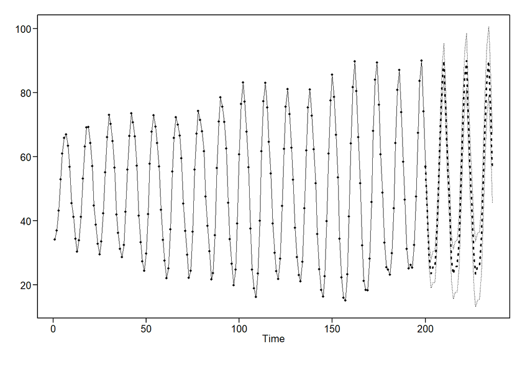

```
## $f
##  [1] 44.51711 29.07259 23.60548 25.66225 25.70131 33.38056 48.65358 68.32965
##  [9] 84.11652 90.01330 73.85623 56.56400 44.04619 28.73346 23.46486 25.71329
## [17] 25.88320 33.60915 48.85137 68.44668 84.13823 89.95626 73.75590 56.45985
## [25] 43.96935 28.69966 23.47357 25.75178 25.93316 33.65334 48.87836 68.45277
## [33] 84.12667 89.93464 73.73290 56.44247
##
## $ll
##  [1] 42.51188 25.50750 19.06663 20.74594 20.74324 28.39816 43.52612 63.01281
##  [9] 78.67735 84.53921 68.38203 51.07396 37.95225 21.67015 15.69402 17.67706
## [17] 17.82827 25.51937 40.62009 60.04894 75.64186 81.43634 65.23583 47.92171
## [25] 34.98904 18.99868 13.23355 15.31231 15.48203 23.17027 38.27729 57.71671
## [33] 73.31266 79.10314 62.90110 45.59484
##
## $ul
```

[output cut: 73 more lines]

```r
fore.aruma.wge(x,s=12,phi = c(1.47,-0.76),n.ahead = 36,lastn = FALSE)
```

```r
forcast = fore.aruma.wge(x,s=12,phi = c(1.47,-0.76),n.ahead = 36,lastn = TRUE)
```

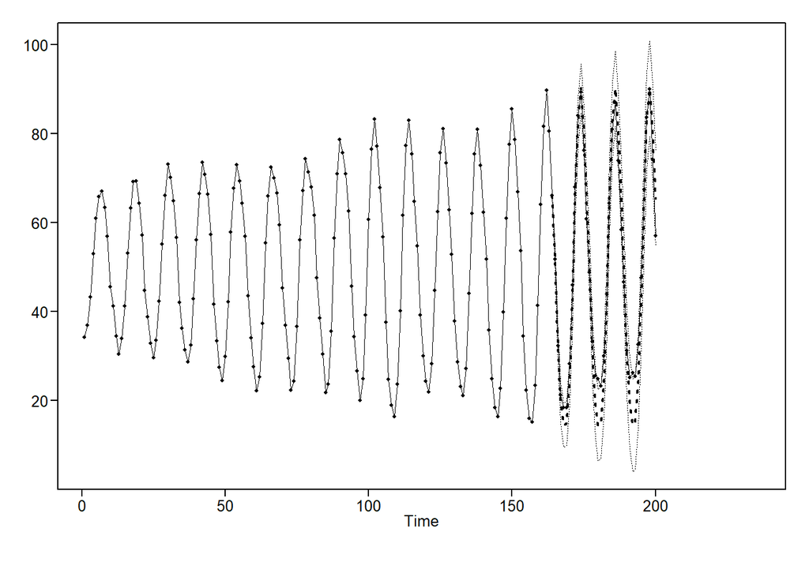

```r
ase = mean((x[(200-36+1):200] - forcast$f)^2)
```

*Summary:*

- The forecasts (open circles) are very close to the true values.
- We were able to fit a model very close to the true model.
- Forecasts (ahead and last 36) are quite good.

### 10.10 Seasonal Models: Example-Airline Data

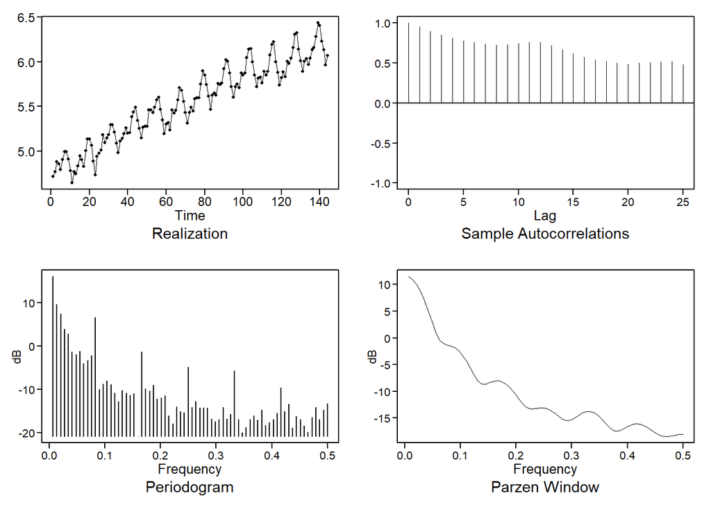

```
## $autplt
##  [1] 1.0000000 0.9537034 0.8989159 0.8508025 0.8084252 0.7788994 0.7564422
##  [8] 0.7376017 0.7271313 0.7336487 0.7442552 0.7580266 0.7619429 0.7165045
## [15] 0.6630428 0.6183629 0.5762087 0.5438013 0.5194561 0.5007029 0.4904028
## [22] 0.4981819 0.5061666 0.5167434 0.5204897 0.4835237
##
## $freq
##  [1] 0.006944444 0.013888889 0.020833333 0.027777778 0.034722222 0.041666667
##  [7] 0.048611111 0.055555556 0.062500000 0.069444444 0.076388889 0.083333333
## [13] 0.090277778 0.097222222 0.104166667 0.111111111 0.118055556 0.125000000
## [19] 0.131944444 0.138888889 0.145833333 0.152777778 0.159722222 0.166666667
## [25] 0.173611111 0.180555556 0.187500000 0.194444444 0.201388889 0.208333333
## [31] 0.215277778 0.222222222 0.229166667 0.236111111 0.243055556 0.250000000
## [37] 0.256944444 0.263888889 0.270833333 0.277777778 0.284722222 0.291666667
## [43] 0.298611111 0.305555556 0.312500000 0.319444444 0.326388889 0.333333333
```

[output cut: 32 more lines]

```r
data("airlog")
lair=ts(airlog)
plotts.sample.wge(airlog)
```

```r
est.lair=est.ar.wge(lair,p=15,type='burg')
```

```
##
## Coefficients of Original polynomial:
## 0.6996 0.2599 0.0079 -0.0646 0.1381 -0.0953 0.0235 -0.0969 0.1770 -0.1191 0.1030 0.7754 -0.4590 -0.4099 0.0501
##
## Factor                 Roots                Abs Recip    System Freq
## 1-1.7253B+0.9953B^2    0.8667+-0.5035i      0.9976       0.0838
## 1-0.9861B+0.9950B^2    0.4955+-0.8715i      0.9975       0.1677
## 1+0.9869B+0.9850B^2   -0.5010+-0.8742i      0.9925       0.3328
## 1-0.0375B+0.9788B^2    0.0192+-1.0106i      0.9893       0.2470
## 1-1.9697B+0.9704B^2    1.0149+-0.0218i      0.9851       0.0034
## 1+1.6891B+0.9504B^2   -0.8886+-0.5124i      0.9749       0.4168
## 1+0.8540B             -1.1709               0.8540       0.5000
## 1+0.6000B             -1.6667               0.6000       0.5000
## 1-0.1110B              9.0072               0.1110       0.0000
##
##
```

Matching up the factor tables it could have a (1-B^12).

*Note:*

- Factor tables for other high orders are similar
- The factor $1-1.9697B+0.9704B^2$ is associated with a frequency of $f_0$ = 0.0034 or a period of 1/.0034 = 294 (longer than the data record). This suggests aperiodic data or a very long period.
- Also this factor is very close to $1-2B+B2 = (1-B)2$ which is associated with frequency $f_0 = 0$
  - We encountered a similar situation with an ARIMA model with $d=2$.
  - $(1-B)^2$ provides the last “piece” needed for a factor of $(1-B^{12})$ plus an extra $(1-B)$ factor
  - That is, the factor table suggests the presence of nonstationary factors $(1-b)(1-B^{12})$
- Although $(1+.85B)$ is not as close to the unit circle “as we would expect for $s=12$ data, the”total picture" suggests a factor of $(1-B^{12})$

**In the log airline factor table** $(1-B)^2$ provides the last “piece” needed for a factor of $(1-B^{12})$ plus an extra (1-B) factor

**Recall:** We earlier discussed the following model that is useful for modeling seasonal data with a trend

$$(1-B)(1-B^s)\phi(B)(X_t-\mu)=\theta(B)a_t$$

We referred to it as the **airline model**,for obvious reasons!

**Note:** The airline model allows for stationary components * To find these, we transform to find $Y_t=(1-B)(1-B^{12})X_t$

#### Transform to Stationarity

Using tswge to transform log airline data (lair) to remove seasonal and ARIMA components

```r
#Difference the data
d1=artrans.wge(lair,phi.tr=1)
```

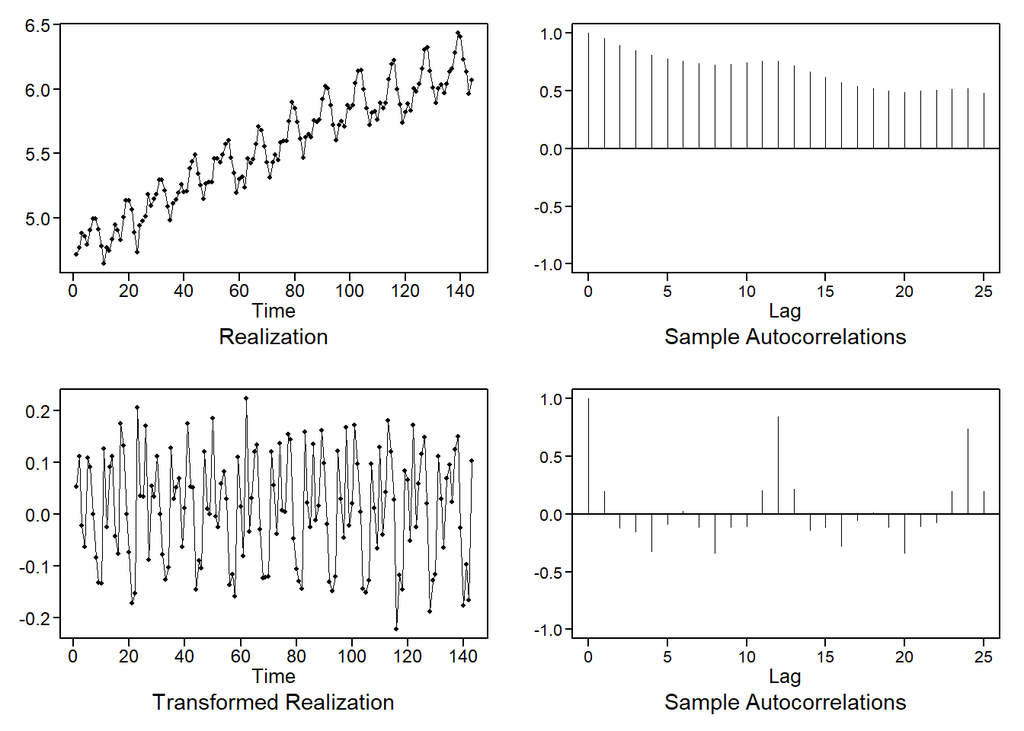

- Trend has been removed
- 12 month seasonal behavior remains

#### Differenced Data Transformed by $(1-B^{12})$

```r
# Transform differenced data with "seasonal difference"
d1.12=artrans.wge(d1,phi.tr=c(0,0,0,0,0,0,0,0,0,0,0,1))
```

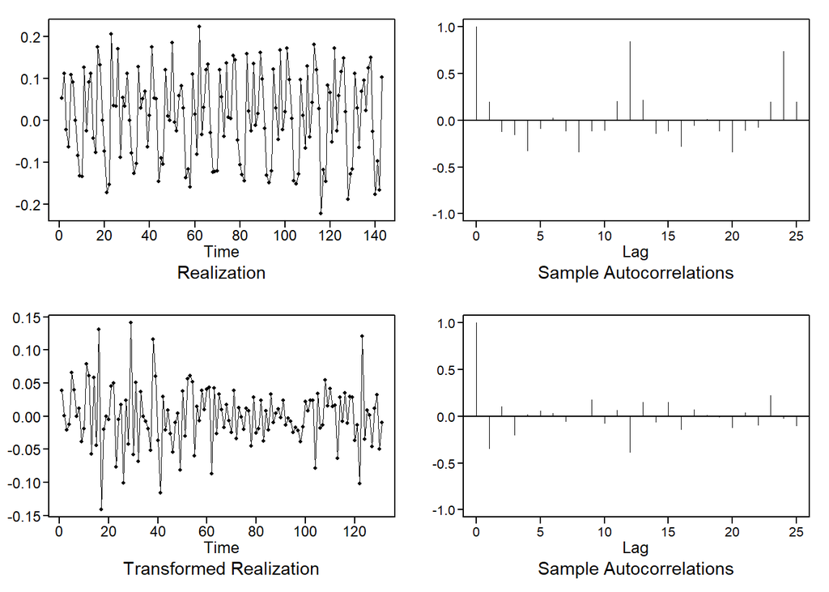

- Appears to be stationary
- No trending or seasonality present
- We will find a stationary model for this realization

#### Finding a Final Model for the (log) Airline Data

Use **tswge** to model the transformed data, d1.12 (twice transformed data)

```r
aic5.wge(d1.12,p=0:13,q=0:3)
```

```
## ---------WORKING... PLEASE WAIT...
##
##
## Five Smallest Values of  aic
```

|  | p | q | aic |
| --- | --- | --- | --- |
| 50 | 12 | 1 | -6.423649 |
| 53 | 13 | 0 | -6.413487 |
| 54 | 13 | 1 | -6.411660 |
| 51 | 12 | 2 | -6.410749 |
| 49 | 12 | 0 | -6.404858 |

AIC picks an **ARMA(12,1)**. * In order to see if a lower order model could satisfactorily model the data, we use BIC

```r
aic5.wge(d1.12,p=0:13,q=0:3,type='bic')
```

```
## ---------WORKING... PLEASE WAIT...
##
##
## Five Smallest Values of  bic
```

|  | p | q | bic |
| --- | --- | --- | --- |
| 2 | 0 | 1 | -6.231113 |
| 5 | 1 | 0 | -6.223197 |
| 6 | 1 | 1 | -6.196229 |
| 4 | 0 | 3 | -6.195271 |
| 3 | 0 | 2 | -6.194583 |

BIC picks an **MA(1)** as the first choice and an **AR(1)** as second choice.

- Examining the data and sample autocorrelations, neither model seems appropriate
- We decide to use the ARMA(12,1) model chosen by AIC

```r
est.d1.12=est.arma.wge(d1.12,p=12,q=1)
```

```
##
## Coefficients of Original polynomial:
## 0.0085 0.0797 -0.1071 -0.0207 0.0804 0.0405 -0.0552 0.0363 0.1328 -0.0530 -0.1234 -0.4034
##
## Factor                 Roots                Abs Recip    System Freq
## 1-1.3375B+0.9189B^2    0.7278+-0.7474i      0.9586       0.1271
## 1-0.4595B+0.9145B^2    0.2512+-1.0151i      0.9563       0.2114
## 1-1.8218B+0.8847B^2    1.0296+-0.2650i      0.9406       0.0401
## 1+1.8049B+0.8709B^2   -1.0363+-0.2728i      0.9332       0.4590
## 1+1.2840B+0.8214B^2   -0.7816+-0.7788i      0.9063       0.3753
## 1+0.5214B+0.7586B^2   -0.3436+-1.0955i      0.8710       0.2984
##
##
```

```r
est.d1.12$phi
```

```
##  [1]  0.00846435  0.07967002 -0.10710183 -0.02069279  0.08039524  0.04050674
##  [7] -0.05516681  0.03629598  0.13277817 -0.05297698 -0.12340975 -0.40343184
```

```r
est.d1.12$theta
```

```
## [1] 0.4536856
```

```r
est.d1.12$avar
```

```
## [1] 0.001310444
```

```r
mean(lair)
```

```
## [1] 5.542176
```

**Comments**

- Recall from an earlier unit that forecasts using the airline model are quite good + We previously used the **AR(13) (Woodward / Gray Model)** instead of the **ARMA(12,1) (Box Model)** but forecasts are very similar
- Recall also that $(1-B)(1-B^{12})$ contains two factors of $(1-B)$ which accounts for the fact that the trend in the airline data is predicted to continue
- It is clear that seasonal models are useful for data that occur monthly or quarterly or some other sampling interval where similar patterns are likely to be repeated

#### Pennsylvania Temperature Data

The data set is available in tswge.

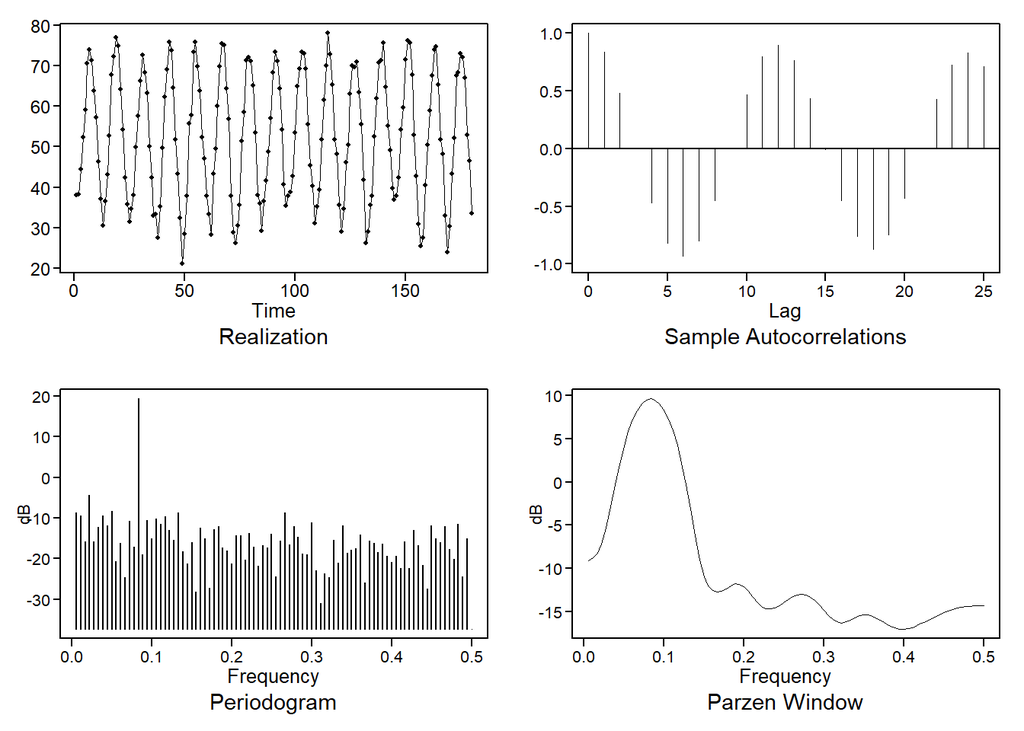

```
## $autplt
##  [1]  1.0000000000  0.8386381052  0.4803421817 -0.0010081916 -0.4717907055
##  [6] -0.8176935421 -0.9340050360 -0.7999823229 -0.4527311287  0.0089564844
## [11]  0.4659219410  0.7959391935  0.9002977221  0.7656850843  0.4360703243
## [16] -0.0098189556 -0.4511591540 -0.7618069185 -0.8701222437 -0.7482146632
## [21] -0.4297051103  0.0008229813  0.4253734168  0.7280472951  0.8317412380
## [26]  0.7119144914
##
## $freq
##  [1] 0.005555556 0.011111111 0.016666667 0.022222222 0.027777778 0.033333333
##  [7] 0.038888889 0.044444444 0.050000000 0.055555556 0.061111111 0.066666667
## [13] 0.072222222 0.077777778 0.083333333 0.088888889 0.094444444 0.100000000
## [19] 0.105555556 0.111111111 0.116666667 0.122222222 0.127777778 0.133333333
## [25] 0.138888889 0.144444444 0.150000000 0.155555556 0.161111111 0.166666667
## [31] 0.172222222 0.177777778 0.183333333 0.188888889 0.194444444 0.200000000
```

[output cut: 43 more lines]

```r
data('patemp')  # the data set is available in tswge
plotts.sample.wge(patemp)
```

There certainly seems to be a “seasonal” pattern Autocorrelations damp slowly **Again!** Use overfit procedure

```r
est.ar.wge(patemp,p=14,type='burg')
```

```
##
## Coefficients of Original polynomial:
## 0.4595 0.1428 -0.0434 -0.0319 -0.2592 -0.0400 0.0205 -0.0032 0.0079 -0.0008 0.2556 0.0619 -0.0307 -0.0057
##
## Factor                 Roots                Abs Recip    System Freq
## 1-1.7267B+0.9971B^2    0.8659+-0.5032i      0.9985       0.0838
## 1-0.9007B              1.1103               0.9007       0.0000
## 1+0.1854B+0.8005B^2   -0.1158+-1.1117i      0.8947       0.2665
## 1-0.8397B+0.7441B^2    0.5642+-1.0127i      0.8626       0.1691
## 1+0.9827B+0.6948B^2   -0.7072+-0.9691i      0.8335       0.3503
## 1+1.5999B+0.6922B^2   -1.1557+-0.3304i      0.8320       0.4557
## 1+0.4007B             -2.4954               0.4007       0.5000
## 1-0.3283B              3.0459               0.3283       0.0000
## 1+0.1672B             -5.9806               0.1672       0.5000
##
##
```

```
## $phi
##  [1]  0.4594659903  0.1427551082 -0.0434246728 -0.0318807517 -0.2592267573
##  [6] -0.0399905496  0.0204923286 -0.0032387719  0.0079453724 -0.0008409617
## [11]  0.2556092284  0.0618838344 -0.0306541940 -0.0056589802
##
## $res
##   [1]  1.42453903  0.03669644  1.18825252  0.97662605 -0.67170349  4.74616673
##   [7]  2.84763022  1.00841613 -0.22011746  1.80269417 -0.02599913 -1.72873686
##  [13] -4.02668684  1.81933977  1.44201569  1.52905167  5.46930764 -0.82673677
##  [19]  2.48509718  3.02852421 -2.07528604  0.79863877 -0.49922942  2.13751686
##  [25] -0.14010848 -0.33305960 -4.08835303 -2.05479182 -4.07783625 -2.49910387
##  [31]  0.82612150 -2.76544983  0.15070884 -3.80836261 -0.46602137 -1.68132687
##  [37]  1.37629478 -6.77406889 -4.01034984  2.54143512  2.29049421 -0.61918027
##  [43]  1.85269194  0.28621165 -0.24320291 -1.88480443  1.62374253 -2.26351865
##  [49] -7.55054890  1.46145425  0.41623850  5.63461172 -6.93660457  0.89650216
```

[output cut: 33 more lines]

```r
est.ar.wge(patemp,p=15,type='burg')
```

```
##
## Coefficients of Original polynomial:
## 0.4591 0.1409 -0.0397 -0.0163 -0.2593 -0.0395 0.0203 -0.0020 0.0055 -0.0166 0.2537 0.0592 -0.0220 0.0223 -0.0608
##
## Factor                 Roots                Abs Recip    System Freq
## 1-1.7268B+0.9973B^2    0.8657+-0.5032i      0.9987       0.0838
## 1-0.8743B              1.1438               0.8743       0.0000
## 1-0.8987B+0.7623B^2    0.5894+-0.9820i      0.8731       0.1640
## 1+0.2200B+0.7559B^2   -0.1455+-1.1410i      0.8694       0.2702
## 1+1.0663B+0.7499B^2   -0.7109+-0.9100i      0.8660       0.3556
## 1+1.6060B+0.7278B^2   -1.1034+-0.3957i      0.8531       0.4452
## 1+0.7830B             -1.2772               0.7830       0.5000
## 1+0.0141B+0.4368B^2   -0.0161+-1.5130i      0.6609       0.2517
## 1-0.6487B              1.5415               0.6487       0.0000
##
##
```

```
## $phi
##  [1]  0.459121742  0.140890347 -0.039660145 -0.016331489 -0.259277915
##  [6] -0.039507215  0.020295307 -0.001992179  0.005512661 -0.016610286
## [11]  0.253669853  0.059242218 -0.021970092  0.022291330 -0.060832164
##
## $res
##   [1]  1.57779122  0.21364892  1.30718260  0.95749744 -0.72025601  4.72508521
##   [7]  2.81243193  0.95753603 -0.26718205  1.82988212  0.01164540 -1.72062063
##  [13] -4.01531599  1.81211264  1.43667944  1.73116849  5.63703336 -0.66717902
##  [19]  2.60440319  2.88025069 -2.06387723  0.84148271 -0.58767886  1.99070785
##  [25] -0.01862306 -0.16958670 -3.86842454 -2.19288253 -3.92004763 -2.39832115
##  [31]  0.80087180 -2.44747878  0.25091439 -3.61873456 -0.21857200 -1.63868285
##  [37]  1.38102753 -6.83442031 -4.05679148  2.46084296  2.37221132 -0.66402356
##  [43]  1.99811501  0.11055028 -0.43735704 -1.85081584  1.47557701 -2.35931331
##  [49] -7.85224302  1.40374635  0.24283831  5.99621866 -6.92984324  0.72864513
```

[output cut: 33 more lines]

** Factor Tables for Pennsylvania Temperature Data **

```
* These factor tables are not what we expected
    + We expected to see the factors of $(1-B^{12})$ approximated by factors with roots very close to the unit circle
    + This is what we saw in the previous two seasonal examples
* The only factor of $(1-B^{12})$ that has the behavior we expected is $(1-1.732B+B^2)$
    + Each factor table had a factor very close to this one with roots close to the unit circle
* This suggests that the stationarizing transformation is $Y_t=(1-1.732B+B^2 )X_t$
```

** We Transform the Data by: **

$Y_t=(1-1.732B+B^2 )X_t$

```r
y.tr=artrans.wge(patemp,phi.tr=c(1.732,-1))
```

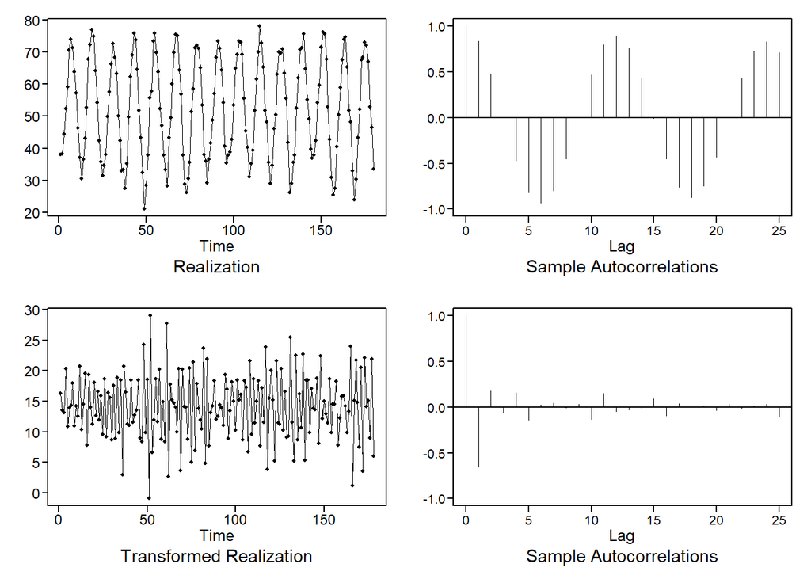

The transformed data appear stationary

```r
aic5.wge(y.tr,p=0:13, q=0:3)
```

```
## ---------WORKING... PLEASE WAIT...
##
##
## Five Smallest Values of  aic
```

|  | p | q | aic |
| --- | --- | --- | --- |
| 37 | 9 | 0 | 2.344750 |
| 41 | 10 | 0 | 2.352889 |
| 38 | 9 | 1 | 2.353473 |
| 54 | 13 | 1 | 2.355932 |
| 50 | 12 | 1 | 2.360297 |

Using aic5.wge with p=0:13, q=0:3, an AR(9) is selected

```r
aic5.wge(y.tr,p=0:13, q=0:3,type = 'bic')
```

```
## ---------WORKING... PLEASE WAIT...
##
##
## Five Smallest Values of  bic
```

|  | p | q | bic |
| --- | --- | --- | --- |
| 13 | 3 | 0 | 2.493018 |
| 17 | 4 | 0 | 2.512010 |
| 14 | 3 | 1 | 2.514841 |
| 37 | 9 | 0 | 2.523501 |
| 22 | 5 | 1 | 2.524980 |

Using aic5.wge with the same range for p and q and using BIC, an AR(3) is selected Let’s go with the simpler model

```r
est.patemp=est.ar.wge(y.tr,p=3)
```

```
##
## Coefficients of Original polynomial:
## -1.1426 -0.8432 -0.4145
##
## Factor                 Roots                Abs Recip    System Freq
## 1+0.7536B             -1.3270               0.7536       0.5000
## 1+0.3890B+0.5500B^2   -0.3536+-1.3012i      0.7416       0.2922
##
##
##
## Coefficients of Original polynomial:
## -1.1426 -0.8432 -0.4145
##
## Factor                 Roots                Abs Recip    System Freq
## 1+0.7536B             -1.3270               0.7536       0.5000
## 1+0.3890B+0.5500B^2   -0.3536+-1.3012i      0.7416       0.2922
##
##
```

```r
est.patemp$phi
```

```
## [1] -1.1425939 -0.8431575 -0.4144801
```

```r
est.patemp$avar
```

```
## [1] 10.76795
```

```r
mean(patemp)
```

```
## [1] 52.62667
```

Final model:
$$(1-1.732B+B^2)(1+1.14B+0.84B^2+0.41B^3)(X_t-52.63)=a_t\ \sigma^2_a=10.77$$

**Note:**

- The above model is an example of what Woodward, et al., 2017, refer to as an **ARUMA** model
- It is a more general nonstationary model that can contain roots on the unit circle that are not necessarily +1
- Seasonal models are ARUMA models

**Do not** include $(1-B^{12})$, for example, in the model simply because there is a 12th order nonstationarity or because the data show a period of 12 or just because you have monthly data

### 10.12 Signal Plus Noise Models: Testing for Trend OLS Method

**Concept Check 10.12.2**

Please use the data you create from the below steps to answer this and the next two Concept Check questions.

We would like to test the type I error rate of the OLS (ordinary least squares) estimates of the slope when the residuals are correlated. To do this we will generate a realization from a model with no trend $(b1 = 0)$ and see how often $Ho:\beta_1=0$ is rejected.

**Step 1:** We want to generate a realization with no trend but with correlated residuals.

$$X_t=0+0_t+Z_t$$
$Z_t$ is generated from an **AR(1)** model with phi=0.95: $(1-0.95B)Z_t=a_t$

To do this, run the following code:

```r
x = gen.sigplusnoise.wge(100, b0 = 0, b1= 0, phi= .95, sn = 28)
```

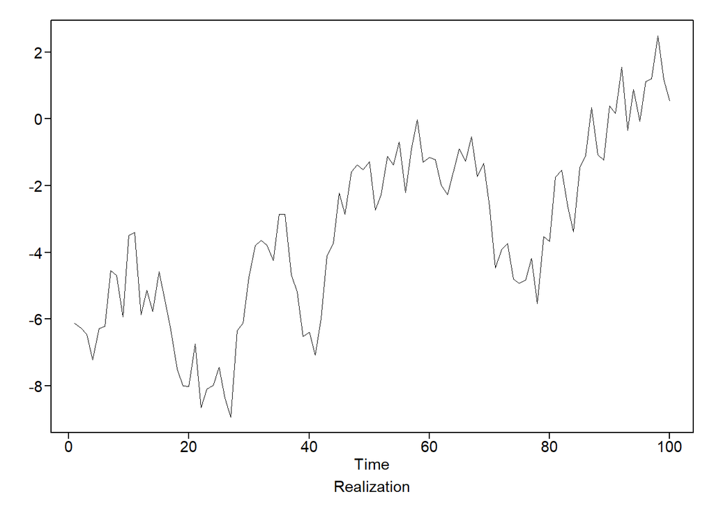

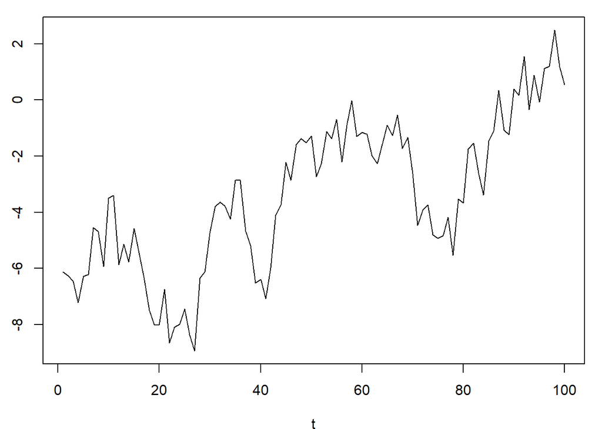

**Step 2:** Fit a regression line to the data using the following code:

```r
t = seq(1,100,1)
df = data.frame(x = x, t= t)
fit = lm(x~t, data = df)
summary(fit)
```

```
##
## Call:
## lm(formula = x ~ t, data = df)
##
## Residuals:
##     Min      1Q  Median      3Q     Max
## -4.0481 -1.3425  0.3966  1.3192  2.8725
##
## Coefficients:
##              Estimate Std. Error t value            Pr(>|t|)
## (Intercept) -7.032983   0.355453  -19.79 <0.0000000000000002 ***
## t            0.071204   0.006111   11.65 <0.0000000000000002 ***
## ---
## Signif. codes:  0 '***' 0.001 '**' 0.01 '*' 0.05 '.' 0.1 ' ' 1
##
## Residual standard error: 1.764 on 98 degrees of freedom
## Multiple R-squared:  0.5808, Adjusted R-squared:  0.5765
## F-statistic: 135.8 on 1 and 98 DF,  p-value: < 0.00000000000000022
```

What is the p-value for the test?

- $Ho:\beta_1=0$
- $Ha:\beta_1???0$

**Much smaller than .05**

Does this test suggest that there is a trend (nonzero slope)?

** Yes, Even though we know that there is not a trend.**

Was this a type I error?

** Yes, We rejected when $Ho:\beta_1=0$ was true.**

Was this a fluke?

We would now like to investigate just how common it is to conclude that there is a trend when there actually is not a trend (stationary process).

Remember that if **alpha = .05**, then the test should find significant slope when none is present about 5 percent of the time. This means that if we generated a realization with no trend 10 times, we would not be surprised to see zero or one rejections (type I errors).

Let’s experiment and see what you get. Simply run the following code and respond to the free response/discussion question.

Run this code 10 times, and record how many out of 10 it rejected (type I error).

```r
#note that there is not a seed this time. We will generate a different realization each time.
x = gen.sigplusnoise.wge(100, b0 = 0, b1= 0, phi= .99)
```

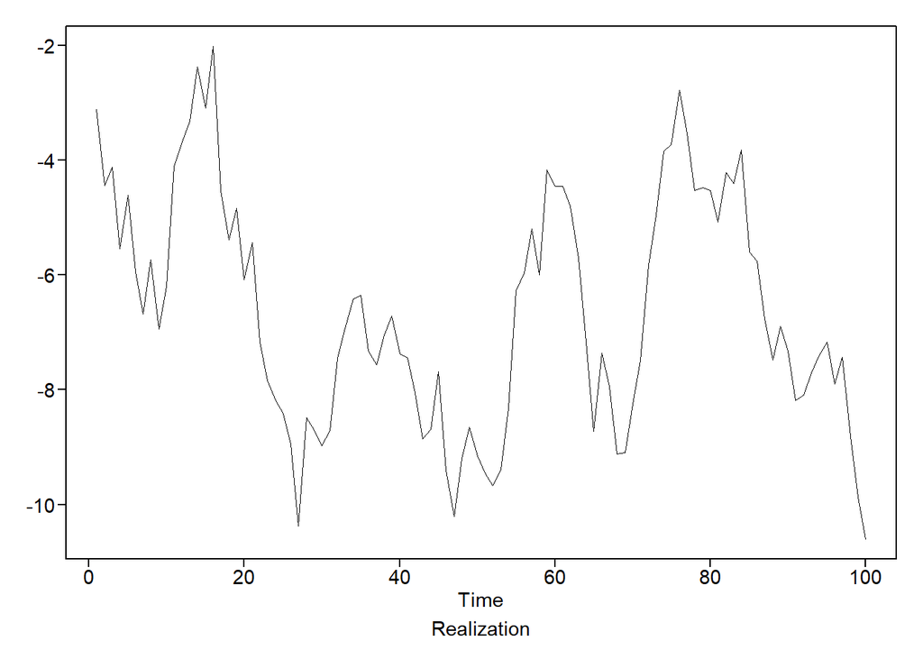

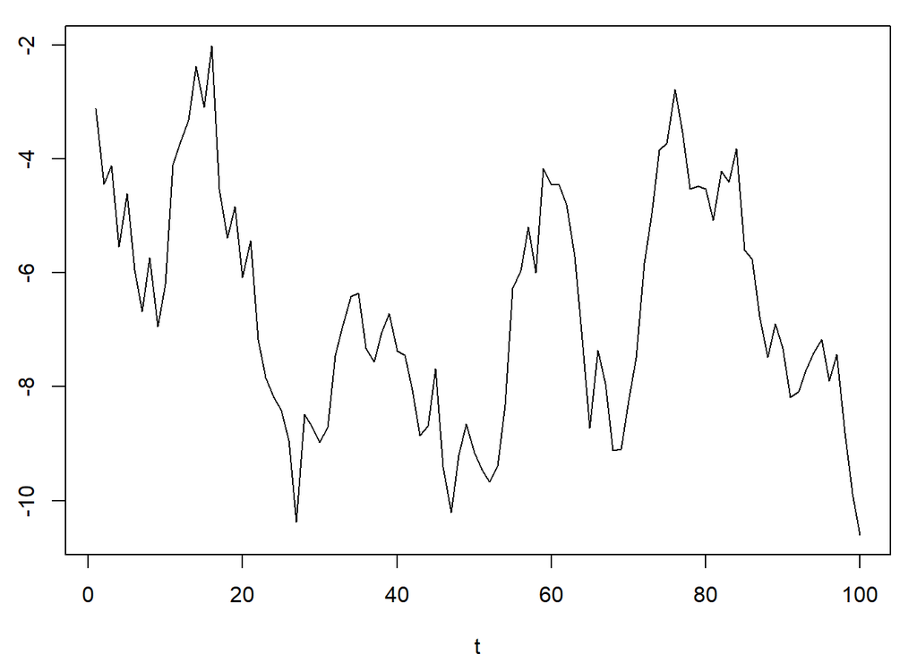

```r
t = seq(1,100,1)
df = data.frame(x = x, t= t)
fit = lm(x~t, data = df)
summary(fit) # record whether it rejected or failed to reject.
```

```
##
## Call:
## lm(formula = x ~ t, data = df)
##
## Residuals:
##     Min      1Q  Median      3Q     Max
## -4.0547 -1.5688 -0.2213  1.5834  4.1704
##
## Coefficients:
##             Estimate Std. Error t value            Pr(>|t|)
## (Intercept) -5.97617    0.40602 -14.719 <0.0000000000000002 ***
## t           -0.01283    0.00698  -1.838               0.069 .
## ---
## Signif. codes:  0 '***' 0.001 '**' 0.01 '*' 0.05 '.' 0.1 ' ' 1
##
## Residual standard error: 2.015 on 98 degrees of freedom
## Multiple R-squared:  0.03333,    Adjusted R-squared:  0.02347
## F-statistic: 3.379 on 1 and 98 DF,  p-value: 0.06904
```

Comment below on how many out of 10 rejected $H_o:\beta_1=0$ and whether you were surprised or alarmed.

**This is a really bad way to test for trend in time series data** * You will detect a (deterministic) trend in many cases in which no such trend exists * The test is picking up on the random trends in AR(1) data

#### Cochrane-Orcutt in R

```r
#install.packages("orcutt")
library(orcutt)
#Generate some data
x = gen.sigplusnoise.wge(500, b0 = 0, b1= 0, phi= .95, sn = 21)
```

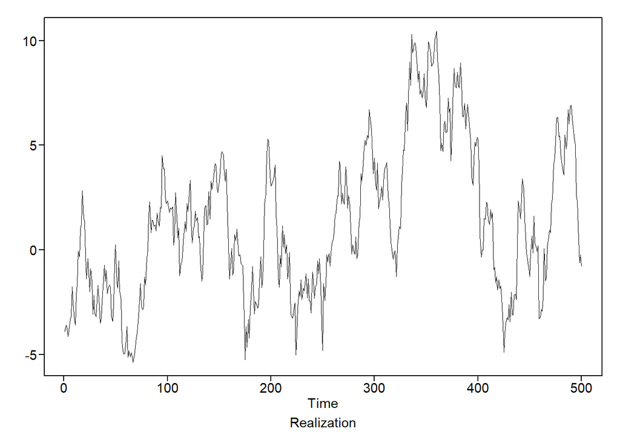

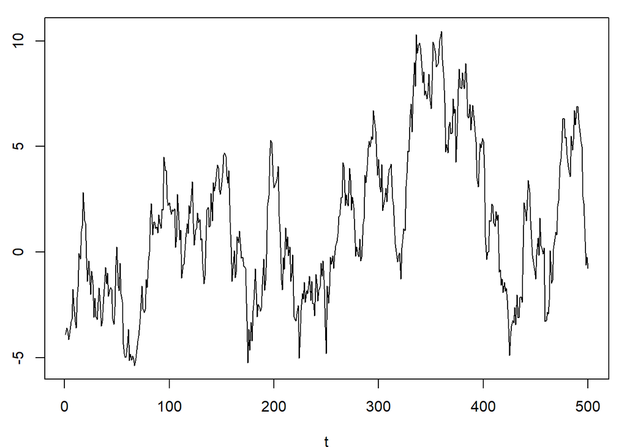

This is the old way:

```r
#Generate a sequence
t = seq(1,500,1)
df = data.frame(x = x, t= t)
fit = lm(x~t, data = df)
summary(fit)
```

```
##
## Call:
## lm(formula = x ~ t, data = df)
##
## Residuals:
##     Min      1Q  Median      3Q     Max
## -8.0696 -2.3978 -0.1244  2.3635  8.1129
##
## Coefficients:
##              Estimate Std. Error t value             Pr(>|t|)
## (Intercept) -1.434081   0.293479  -4.886           0.00000139 ***
## t            0.010818   0.001015  10.657 < 0.0000000000000002 ***
## ---
## Signif. codes:  0 '***' 0.001 '**' 0.01 '*' 0.05 '.' 0.1 ' ' 1
##
## Residual standard error: 3.276 on 498 degrees of freedom
## Multiple R-squared:  0.1857, Adjusted R-squared:  0.1841
## F-statistic: 113.6 on 1 and 498 DF,  p-value: < 0.00000000000000022
```

Now use the **Cochrane-Orcutt** method by just pasing our data to it.

```r
cfit = cochrane.orcutt(fit)
summary(cfit)
```

```
## Call:
## lm(formula = x ~ t, data = df)
##
##               Estimate Std. Error t value Pr(>|t|)
## (Intercept) -0.5344211  2.0618730  -0.259   0.7956
## t            0.0071777  0.0067080   1.070   0.2851
##
## Residual standard error: 1.0026 on 497 degrees of freedom
## Multiple R-squared:  0.0023 ,  Adjusted R-squared:  0.0003
## F-statistic: 1.1 on 1 and 497 DF,  p-value: < 2.851e-01
##
## Durbin-Watson statistic
## (original):    0.09566 , p-value: 1.046e-101
## (transformed): 2.02773 , p-value: 6.046e-01
```

**10.13.3 Check*

**Consider again the Southwest Airlines delay data (SWADelay.csv particularly the arr_delay column).**

Management wants to know if there is evidence that the mean delay is increasing over time, or if the recent increase is a “random trend” and can be expected to revert back to some lesser mean number of delays in the future.

Looking at the data, it looks like there is a trend, but is it real?

Fit a simple linear regression to the data using arr_delay as the response and time as the explanatory variable (you will have to create this variable).

**What is the p-value?**

```r
#Generate a sequence
SWA.coc_or=SWA$arr_delay
#convert to a time series
SWA.coc_or=ts(SWA.coc_or)
t = seq(1,177,1)
df = data.frame(x = SWA.coc_or, t= t)
fit = lm(x~t, data = df)
summary(fit)
```

```
##
## Call:
## lm(formula = x ~ t, data = df)
##
## Residuals:
##    Min     1Q Median     3Q    Max
## -27333  -9966  -2373   9000  43874
##
## Coefficients:
##             Estimate Std. Error t value             Pr(>|t|)
## (Intercept) 20680.32    2231.07   9.269 < 0.0000000000000002 ***
## t             160.16      21.74   7.367      0.0000000000066 ***
## ---
## Signif. codes:  0 '***' 0.001 '**' 0.01 '*' 0.05 '.' 0.1 ' ' 1
##
## Residual standard error: 14780 on 175 degrees of freedom
## Multiple R-squared:  0.2367, Adjusted R-squared:  0.2324
## F-statistic: 54.27 on 1 and 175 DF,  p-value: 0.000000000006603
```

```r
cfit = cochrane.orcutt(fit)
summary(cfit)
```

```
## Call:
## lm(formula = x ~ t, data = df)
##
##              Estimate Std. Error t value     Pr(>|t|)
## (Intercept) 21077.921   3844.600   5.482 0.0000001455 ***
## t             156.428     37.067   4.220 0.0000392490 ***
## ---
## Signif. codes:  0 '***' 0.001 '**' 0.01 '*' 0.05 '.' 0.1 ' ' 1
##
## Residual standard error: 12988.43 on 174 degrees of freedom
## Multiple R-squared:  0.0928 ,  Adjusted R-squared:  0.0876
## F-statistic: 17.8 on 1 and 174 DF,  p-value: < 3.925e-05
##
## Durbin-Watson statistic
## (original):    1.03819 , p-value: 3.719e-11
## (transformed): 1.93172 , p-value: 2.973e-01
```

After adjusting for AR(1) errors, is there still significant evidence that as time increases, so will the mean number of delays?

**Yes**